# State of the Neotoma Paleoecology Database

Simon Goring

goring@wisc.edu

true

2022-06-10

## Overall Database Summary

This report largely details changes to the database since **2021-06-10**, and is current up to **2022-06-10**.

In total Neotoma contains data from 44,234 datasets and 19,962 unique sites. This represents a considerable contribution from members of the scientific community, including 3,408 primary investigators, 1,228 analysts, and stewards for all 37 constituent databases. There are also invaluable and incalculable contributions from the members of the Neotoma Paleoecology Database Community.

|  | New Entries |
| --- | --- |
| datasets | 3,813 |
| sites | 1,616 |
| publications | 681 |
| authors | 1,391 |
| countrygpid | 88 |
| observations | 1,361,960 |

### Site additions

[interactive chart not shown]

Locations of newly added sites in Neotoma during the past year. The map is interactive and supports zoom/pan operations. Individual sites can be selected and you will be directed to a link for the [Neotoma Explorer](https://apps.neotomadb.org).

#### Site Metadata

|  | Missing |
| --- | --- |
| sitename | 0 |
| altitude | 20 |
| area | 430 |
| sitedescription | 135 |
| notes | 578 |

#### Dataset Metadata

|  | Missing |
| --- | --- |
| handle | 0 |
| collunitname | 74 |
| colldate | 464 |
| colldevice | 1683 |
| waterdepth | 3198 |
| slopeangle | 3613 |
| aspect | 3613 |
| location | 1897 |
| collunitnotes | 2919 |
| datasetname | 1899 |

[output cut: 1 more lines]

### API Calls

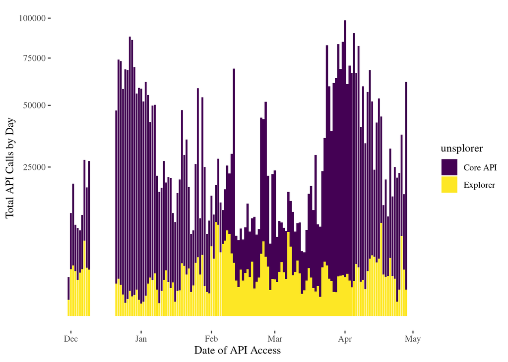

Since the API has been implemented there have been a total of 3,100,203 calls to the Neotoma API. These include calls to the core API ([`api.neotomadb.org`](https://api.neotomadb.org)), calls to support the Neotoma Landing Pages ([`data.neotomadb.org`](https://data.neotomadb.org)) and calls to support Neotoma Explorer ([`apps.neotomadb.org/explorer`](https://data.neotomadb.org)).

Average response time for the web services was 137ms, with a maximum response time of 59.284sec. Approximately 3.19% of all responses took more than one second to return data.

#### Specific API Calls

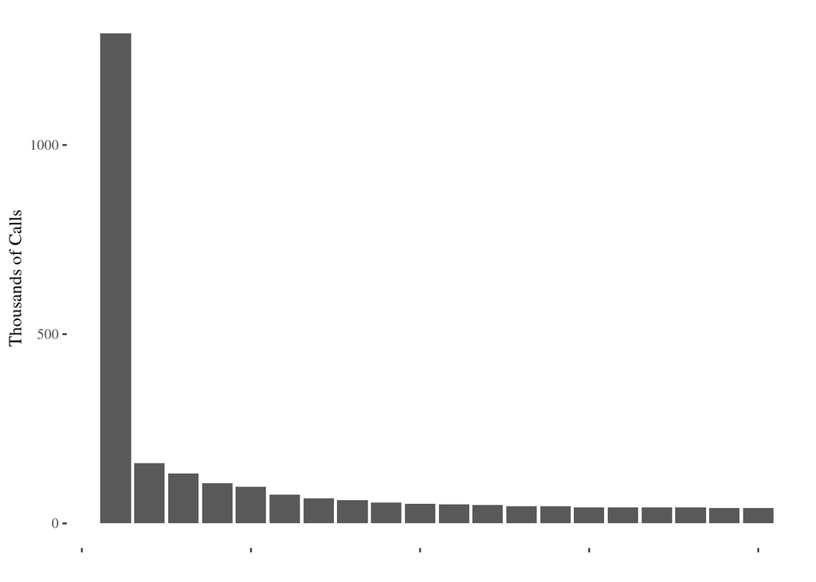

|  | call | n |
| --- | --- | --- |
| 1 | /doc/about | 1294961 |
| 2 | /v1/data/downloads/{n} | 158516 |
| 3 | /v1.5/data/datasets | 132635 |
| 4 | /doc/faq | 105522 |
| 5 | /v2.0/data/downloads/{n} | 96749 |
| 6 | /doc/news | 75968 |
| 7 | /v1/data/datasets | 65702 |
| 8 | /doc/home | 61881 |
| 9 | /doc/examples | 55726 |
| 10 | /doc/resources/datasets | 51812 |

[output cut: 10 more lines]

The slowest API calls (with the slowest *median* response time) are only shown for calls with more than 100 instances:

|  | call | time |
| --- | --- | --- |
| 1 | /v2.0/data/publications | 1989 |
| 2 | /v2.0/data/datasets | 1540 |
| 3 | /v1.5/apps/taxaindatasets | 1394 |
| 4 | /v2.0/data/sites/{n}/datasets | 1057 |
| 5 | /v2.0/data/downloads/{n} | 868 |
| 6 | /v1.5/data/datasets | 812 |
| 7 | /v1.5/data/recentuploads/{n} | 806 |
| 8 | /v2.0/data/datasets_elc | 790 |
| 9 | /v1.5/apps/search | 777 |
| 10 | /v2.0/data/datasets/{n} | 706 |

[output cut: 10 more lines]

### Taxon Overview

There are 42,639 taxa recorded in the Neotoma Taxonomy table. These are not exclusively taxonomic records, but include other variables, such as laboratory measurements and other detected features within samples.

#### Taxon Hierarchy

Taxonomic records are structured hierarchically, with `highertaxonid` pointing to the next highest `taxonid` in the database. **These hierarchies do not necessarily reflect taxonomic hierarchy**. Issues with taxon hierarchy may be the result of improper identification of high level taxa, failure to identify high level taxa, or duplicate records were multiple higher level taxa are identified.

##### Highest-Level Taxa

The highest-level taxa can be identified because they have `taxonid==highertaxonid`. Within the database there are 28 highest level taxa:

|  | taxonid | taxoncode | taxonname | author | valid | highertaxonid | extinct | taxagroupid | publicationid | validatorid | validatedate | notes | recdatecreated | recdatemodified |
| --- | --- | --- | --- | --- | --- | --- | --- | --- | --- | --- | --- | --- | --- | --- |
| 1 | 30 | Bet.pol.diam | Betula mean pollen-grain diameter | Linnaeus | True | 30 | False | BIM |  |  |  |  | 2013-01-01T08:00:00Z | 2013-01-01T08:00:00Z |
| 2 | 312 | ind | Indeterminable |  | True | 312 | False | UPA |  | 44 | 2017-09-29 |  | 2013-01-01T08:00:00Z | 2017-09-29T11:16:06Z |
| 3 | 313 | unk | Unknown |  | True | 313 | False | UPA |  | 44 | 2017-09-29 |  | 2013-01-01T08:00:00Z | 2017-09-29T11:15:56Z |
| 4 | 531 | ca.carb(est) | calcium carbonate (estimated) |  | True | 531 | False | LOI |  | 44 | 2018-05-25 |  | 2013-01-01T08:00:00Z | 2018-05-26T01:08:57Z |
| 5 | 532 | org.mat | organic matter |  | True | 532 | False | CAR |  | 44 | 2015-05-23 |  | 2013-01-01T08:00:00Z | 2017-01-07T05:59:39Z |
| 6 | 1062 | char | Charcoal |  | True | 1062 | False | CHR |  | 44 | 2020-06-02 |  | 2013-01-01T08:00:00Z | 2020-06-03T06:38:05Z |
| 7 | 1414 | unk/ind | Unknown/Indeterminable |  | True | 1414 | False | UPA |  |  |  |  | 2013-01-01T08:00:00Z | 2013-01-01T08:00:00Z |
| 8 | 2054 | Algae | Algae |  | True | 2054 | False | ALG |  | 44 | 2017-10-04 | Algae is an informal term for a polyphyletic group including both Eukaryota and Prokaryota. | 2013-01-01T08:00:00Z | 2017-10-04T09:10:37Z |
| 9 | 2173 | unk/other | Unknown/Other |  | True | 2173 | False | UPA |  | 44 | 2017-09-29 |  | 2013-01-01T08:00:00Z | 2017-09-29T11:16:40Z |
| 10 | 2178 | carb.part | Carbonized particle |  | True | 2178 | False | CHR |  | 44 | 2017-11-01 |  | 2013-01-01T08:00:00Z | 2017-11-02T02:33:24Z |

[output cut: 18 more lines]

This table is provided largely for information, to help identify records that are identified as “highest level”, that should be otherwise grouped.

##### Taxa with no relationships

There are 34,272 taxa that represent “leaves” in the Neotoma taxon tree. Of these, 8,718 have no recorded counts (the `taxonid` does not appear in the `ndb.variables` table). These are taxa that are not part of a morpohotaxonomic hierarchy (so there are no dependent taxa), and also have no associated sample records:

|  | taxonid | taxonname | author | highertaxonid | taxagroupid | count |
| --- | --- | --- | --- | --- | --- | --- |
| 73 | 183 | Mimosoideae | de Candolle, 1825 |  | VPL | 0 |
| 79 | 196 | Osmunda undiff. | Linnaeus, 1753 |  | VPL | 0 |
| 94 | 227 | Polygonella fimbriata/P. myriophylla | (Elliott) Horton, 1963\|(Small) Horton, 1963 |  | VPL | 0 |
| 95 | 229 | Polygonum undiff. | Linnaeus, 1753 |  | VPL | 0 |
| 126 | 303 | Trees undiff. |  |  | VPL | 0 |
| 183 | 471 | Onosmodium | Michaux, 1803 |  | VPL | 0 |
| 185 | 481 | Polygonella | Michaux, 1803 |  | VPL | 0 |
| 192 | 499 | Urticales undiff. | Jussieu ex Berchtold &amp; J. Presl, 1820 |  | VPL | 0 |
| 219 | 560 | Amphitrema flavum | Archer, 1877 |  | TES | 0 |
| 255 | 609 | Difflugia oviformis | Cash, 1909 |  | TES | 0 |

[output cut: 8708 more lines]

##### Taxa with Undefined Higher Taxa

Some taxa do not have defined `highertaxonid` values. Currently there is a count of 2691 taxa without defined higher taxon IDs. It is unclear why these taxa do not have related higher taxonomic elements.

|  | taxonid | taxonname | author | highertaxonid | taxagroupid | count |
| --- | --- | --- | --- | --- | --- | --- |
| 1 | 14914 | Betula alba | Linnaeus, 1753, nomen ambiguum, nomen rejectum |  | VPL | 0 |
| 2 | 36402 | Anas crecca carolinensis | Gmelin, 1789 |  | AVE | 0 |
| 3 | 41619 | Blechnum tabulare | (Thunberg) Kuhn, 1868 |  | VPL | 0 |
| 4 | 2335 | Lilianae (monocolpate) | Takhtajan, 1967 |  | VPL | 0 |
| 5 | 15008 | Felis atrox | Leidy, 1853 |  | MAM | 0 |
| 6 | 37902 | Lightfootia | L'Héritier, 1788[1789], nomen illegitimum |  | VPL | 0 |
| 7 | 40143 | Myrica serrata | Lamarck, 1786 |  | VPL | 0 |
| 8 | 28425 | Opuntia erinacea | Engelmann &amp; J.M. Bigelow, 1856 |  | VPL | 0 |
| 9 | 25305 | Unknown-BC01-9-2 | Peros et al., 2010 |  | DIA | 0 |
| 10 | 35634 | Taxidea marylandica | Gidley &amp; Gazin, 1933 |  | MAM | 0 |

[output cut: 2681 more lines]

#### Duplicated Taxa

Taxa are identified by `taxonname` and `taxagroupid`. There are instances of duplicate `taxonname`, but these should be represented by distinct `taxagroupid` values. There are 50 taxa where the `taxonname` is duplicated (and the taxon is `valid`).

|  | taxonname | taxagroupid | json_agg |
| --- | --- | --- | --- |
| 1 | Achnatherum robustum | VPL | [ { "id": 28342, "code": "Ahn.ro", "count": 1 }, { "id": 29282, "code": "Ahn.rb", "count": 0 } ] |
| 2 | Alstonia-type | VPL | [ { "id": 41772, "code": "Asn-t", "count": 1 }, { "id": 43089, "code": "Asn-t", "count": 0 } ] |
| 3 | Asterosporium | FUN | [ { "id": 35283, "code": "Astsp", "count": 1 }, { "id": 39261, "code": "Ast", "count": 0 } ] |
| 4 | Bartramiaceae | BRY | [ { "id": 27282, "code": "Bareae", "count": 1 }, { "id": 46173, "code": "Bareae", "count": 0 } ] |
| 5 | Celtis-type | VPL | [ { "id": 46869, "code": "Cel-t.ud", "count": 0 }, { "id": 1415, "code": "Cel-t", "count": 1 } ] |
| 6 | cf. Albizia | VPL | [ { "id": 45801, "code": "cf.Abz", "count": 1 }, { "id": 45814, "code": "cf.Abz", "count": 0 } ] |
| 7 | cf. Cleome | VPL | [ { "id": 31670, "code": "cf.Ceo", "count": 1 }, { "id": 45815, "code": "cf.Cleo", "count": 1 } ] |
| 8 | cf. Gentianaceae | VPL | [ { "id": 4324, "code": "cf.Geneae", "count": 1 }, { "id": 43552, "code": "cf.Geneae", "count": 0 } ] |
| 9 | Cicindela | INS | [ { "id": 21878, "code": "Cix", "count": 0 }, { "id": 21682, "code": "Cic", "count": 0 } ] |
| 10 | Cymbella cf. paucistriata | DIA | [ { "id": 24799, "code": "Cyb.cf.pu", "count": 1 }, { "id": 24817, "code": "Cyb.cf.pa", "count": 0 } ] |

[output cut: 40 more lines]

##### Duplicated Taxon Codes

It is possible to have duplicate taxon codes in the database provided the taxa are within different taxon group IDs. However, there may be instances where a taxon code is repeated within the same group. The following taxon identifiers are repeated multiple times within an ecological group:

|  | taxoncode | taxagroupid | json_agg |
| --- | --- | --- | --- |
| 1 | Asn-t | VPL | [{"id": 41772, "code": "Alstonia-type", "count": 1}, {"id": 43089, "code": "Alstonia-type", "count": 0}] |
| 2 | Bareae | BRY | [{"id": 27282, "code": "Bartramiaceae", "count": 1}, {"id": 46173, "code": "Bartramiaceae", "count": 0}] |
| 3 | cf.Abz | VPL | [{"id": 45801, "code": "cf. Albizia", "count": 1}, {"id": 45814, "code": "cf. Albizia", "count": 0}] |
| 4 | cf.Geneae | VPL | [{"id": 4324, "code": "cf. Gentianaceae", "count": 1}, {"id": 43552, "code": "cf. Gentianaceae", "count": 0}] |
| 5 | Den-t | VPL | [{"id": 1001, "code": "Dennstaedtia-type", "count": 1}, {"id": 46574, "code": "Dennstaedtia-type", "count": 0}] |
| 6 | Dipaca | CRU | [{"id": 31452, "code": "Diplostraca", "count": 0}, {"id": 47147, "code": "Diplostraca", "count": 0}] |
| 7 | Gra-t | VPL | [{"id": 1901, "code": "Grammitis-type", "count": 1}, {"id": 43501, "code": "Grammitis-type", "count": 0}] |
| 8 | Hel-t | VPL | [{"id": 4370, "code": "Heliotropium-type", "count": 1}, {"id": 47410, "code": "Heliotropium-type", "count": 0}] |
| 9 | Hyddae | MOL | [{"id": 28890, "code": "Hydrobiidae", "count": 0}, {"id": 47157, "code": "Hydrobiidae", "count": 0}] |
| 10 | Ixo-t | VPL | [{"id": 20676, "code": "Ixora-type", "count": 1}, {"id": 47435, "code": "Ixora-type", "count": 0}] |

[output cut: 21 more lines]

#### Taxon Synonymys

Although taxonomies are continually updated, Neotoma provides the ability to have users enter the original taxonomic information, and then reference particular synonomies, associated with particular publications, or attributed to specific Neotoma stewards or contacts. This relies on several interacting tables, in particular `ndb.synonyms`, and `ndb.synonomy`. `ndb.synonyms` indicates the links between taxa (in this case `validtaxonid` and `invalidtaxonid`).

Critically, there is no direct *PK*/*FK* link between these tables. Thus, it is possible for a synonymy at the dataset level to have no attribution for the synonymy. While `ndb.synonyms` also provides the opportunity to define a `synonymtype`, the `synonymy` does not, except by relating the `validtaxonid` and `invalidtaxonid` in `ndb.synonyms` to the `taxonid` and `reftaxonid` of `ndb.synonymy`.

The database currently contains 8,911 datasets with synonymys, and a total of 2,690 attributed synonyms. Of the synonyms with associated datastids, there are 205 synonymys without links in the synonyms table. There are 1 synonyms where there is no attributed contactid or publication.

There are 195 synonymys where multiple different publications are used to attribute the synonymy. There are also 491 where multiple different individuals are identified as assigning the synonym. There are 1,370 synonyms without any associated publication.

#### Duplicated Variables

We use variable IDs (PK: `ndb.variables.variableid`) to link a taxon, the element, context and units. In general, we don’t expect that these should ever be duplicated, since we can use the same variable ID over and over again, for the given combination. Having said that, we do see replication, and it’s not clear why.

|  | variableid | taxonid | variableelementid | variableunitsid | variablecontextid | recdatecreated | recdatemodified | count |
| --- | --- | --- | --- | --- | --- | --- | --- | --- |
| 1 | 54866 | 91 | 834 | 19 |  | 2022-02-16T23:36:53Z | 2022-02-16T23:36:53Z | 1 |
| 2 | 54864 | 91 | 834 | 19 |  | 2022-02-16T23:36:53Z | 2022-02-16T23:36:53Z | 4 |
| 3 | 50495 | 697 | 834 | 19 |  | 2021-04-01T13:57:30Z | 2021-04-01T13:57:30Z | 1 |
| 4 | 50496 | 697 | 834 | 19 |  | 2021-04-01T13:57:30Z | 2021-04-01T13:57:30Z | 2 |
| 5 | 44269 | 4047 | 260 | 19 |  | 2019-03-26T21:57:51Z | 2019-03-26T21:57:51Z | 39 |
| 6 | 43649 | 4047 | 260 | 19 |  | 2019-03-11T18:34:37Z | 2020-05-06T03:13:08Z | 4 |
| 7 | 5837 | 5854 | 43 | 26 |  | 2013-09-30T21:03:06Z | 2013-09-30T21:03:06Z | 3 |
| 8 | 5838 | 5854 | 43 | 26 |  | 2013-09-30T21:03:06Z | 2013-09-30T21:03:06Z | 1 |
| 9 | 5843 | 5861 | 43 | 26 |  | 2013-09-30T21:03:06Z | 2013-09-30T21:03:06Z | 1 |
| 10 | 5842 | 5861 | 43 | 26 |  | 2013-09-30T21:03:06Z | 2013-09-30T21:03:06Z | 27 |

[output cut: 43 more lines]

In 53 variables we see that there is duplication of the keys in the `variableids`. Interestingly it seems that this is an issue that primarily affects the mammal records:

|  | taxonid | count | taxonname |
| --- | --- | --- | --- |
| 1 | 91 | 2 | Equisetum |
| 2 | 697 | 2 | Pinus strobus |
| 3 | 4047 | 2 | Dryas octopetala |
| 4 | 5854 | 2 | Atopomys texensis |
| 5 | 5861 | 2 | Bassariscus astutus |
| 6 | 5868 | 2 | Bison bison |
| 7 | 5882 | 4 | Bootherium bombifrons |
| 8 | 5890 | 2 | Brachylagus idahoensis |
| 9 | 5932 | 2 | Castoroides ohioensis |
| 10 | 5949 | 2 | Conepatus leuconotus |

[output cut: 13 more lines]

The ground sloth `Paramylodon harlani` seems to have the biggest issues. Some possible reasons for this larger issue may be associated with the ways “specimens” are added to the database, potentially causing a conflict. This issue should possibly be flagged as a situation where we could add a composite primary key to the table.

### Sites and Datasets

Issues with sites include sites with no associated datasets, duplicated sites and, potentially, sites with missing data.

When we examine sites, we find that there are 582 sites with *exactly* duplicated site geometries. These sites are distributed globally, and distributed across constituent databases.

|  | json_agg | st_asgeojson |
| --- | --- | --- |
| 1 | [{"db": "Latin American Pollen Database", "siteid": 27211, "datasets": [48612, 48613, 48614], "sitename": "Cerro Toledo", "datecreated": "2020-06-26T18:42:48", "datemodified": "2022-05-16T15:38:15"}, … | { "type": "Point", "coordinates": [ -79.111527778, -4.374611111 ] } |
| 2 | [{"db": "Latin American Pollen Database", "siteid": 23758, "datasets": [41116, 41117, 41118], "sitename": "Cocha Caranga Forest", "datecreated": "2019-01-27T23:01:42", "datemodified": "2022-05-16T15:3… | { "type": "Point", "coordinates": [ -79.159583333, -4.045861111 ] } |
| 3 | [{"db": "Latin American Pollen Database", "siteid": 347, "datasets": [355, 7987], "sitename": "Chacaltaya 1", "datecreated": "2013-09-30T14:03:01", "datemodified": "2022-05-16T15:38:15"}, {"db": "Lati… | { "type": "Point", "coordinates": [ -68.15, -16.366667 ] } |
| 4 | [{"db": "Latin American Pollen Database", "siteid": 2572, "datasets": [2665, 8699], "sitename": "Tumbre 1", "datecreated": "2013-09-30T14:03:01", "datemodified": "2022-05-16T15:38:15"}, {"db": "Latin … | { "type": "Point", "coordinates": [ -67.783333, -23.316667 ] } |
| 5 | [{"db": "African Pollen Database", "siteid": 28199, "datasets": [52474, 52475], "sitename": "Gutter", "datecreated": "2021-12-14T22:13:26", "datemodified": "2022-05-16T15:38:15"}, {"db": "African Poll… | { "type": "Point", "coordinates": [ 25.083333333, -30.15 ] } |
| 6 | [{"db": "African Pollen Database", "siteid": 28295, "datasets": [52725], "sitename": "Dega Sala swamp", "datecreated": "2022-02-14T18:41:53", "datemodified": "2022-05-16T15:38:15"}, {"db": "African Po… | { "type": "Point", "coordinates": [ 39.333333333, 7.816666667 ] } |
| 7 | [{"db": "European Pollen Database", "siteid": 3190, "datasets": [4146], "sitename": "Khimaditis", "datecreated": "2013-09-30T14:03:01", "datemodified": "2022-05-16T15:38:15"}, {"db": "European Pollen … | { "type": "Polygon", "coordinates": [ [ [ 21.56513, 40.59702 ], [ 21.63328, 40.59702 ], [ 21.63328, 40.65878 ], [ 21.56513, 40.65878 ], [ 21.56513, 40.59702 ] ] ] } |
| 8 | [{"db": "Neotoma Testate Amoebae Database", "siteid": 27172, "datasets": [48073, 48074, 48075, 48076, 48077, 48078, 48079, 48080, 48081], "sitename": "Elatia BO peatland", "datecreated": "2020-06-11T1… | { "type": "Polygon", "coordinates": [ [ [ 24.29566, 41.47327 ], [ 24.32896, 41.47327 ], [ 24.32896, 41.50182 ], [ 24.29566, 41.50182 ], [ 24.29566, 41.47327 ] ] ] } |
| 9 | [{"db": "European Pollen Database", "siteid": 15855, "datasets": [24403], "sitename": "Les Enfrus", "datecreated": "2018-01-17T07:38:15", "datemodified": "2022-05-16T15:38:15"}, {"db": "European Polle… | { "type": "Point", "coordinates": [ 2.892222222, 44.803055556 ] } |
| 10 | [{"db": "European Pollen Database", "siteid": 3093, "datasets": [4028, 8957], "sitename": "Embouchac", "datecreated": "2013-09-30T14:03:01", "datemodified": "2022-05-16T15:38:15"}, {"db": "European Po… | { "type": "Point", "coordinates": [ 3.916667, 43.566389 ] } |

[output cut: 572 more lines]